# Chapter6

Amanda P

1/24/2018

# 6.2.1 Exercises

1. What happens if you pair a discrete variable to a continuous scale? What happens if you pair a continuous variable to a discrete scale?

Pairing a discrete variable to a continous scale gives an error: `Error: Discrete value supplied to continuous scale`

Pairing a continuous variable to a discrete scale works. Here is an example:

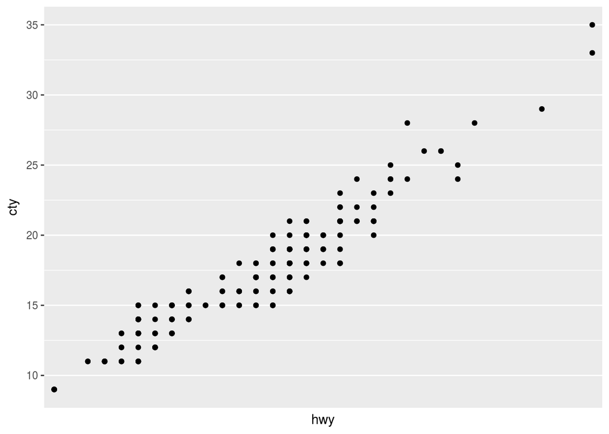

```r
ggplot(mpg,aes(hwy,cty)) + geom_point() + scale_x_discrete()
```

We see that the x axis breaks and associated labels disappear.

2. Simplify the following plot specifications to make them easier to understand.

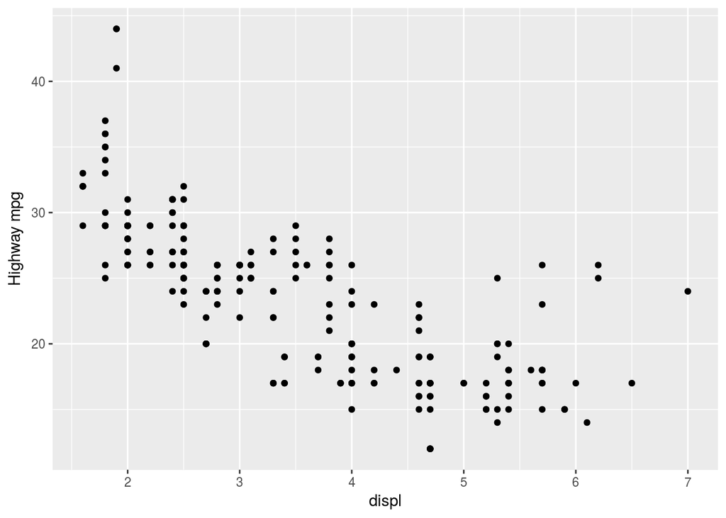

```r
#original:
ggplot(mpg,aes(displ)) + scale_y_continuous("Highway mpg") + scale_x_continuous() + geom_point(aes(y=hwy))
```

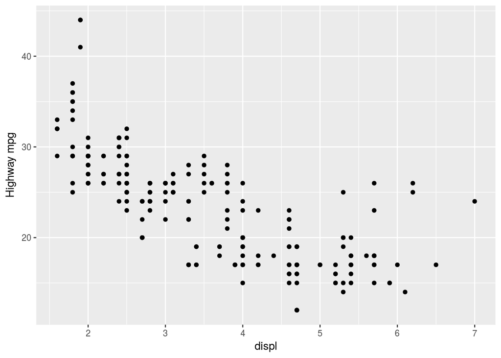

```r
#simplified version:
ggplot(mpg,aes(displ,hwy)) + scale_y_continuous("Highway mpg") + geom_point()
```

[output not shown]

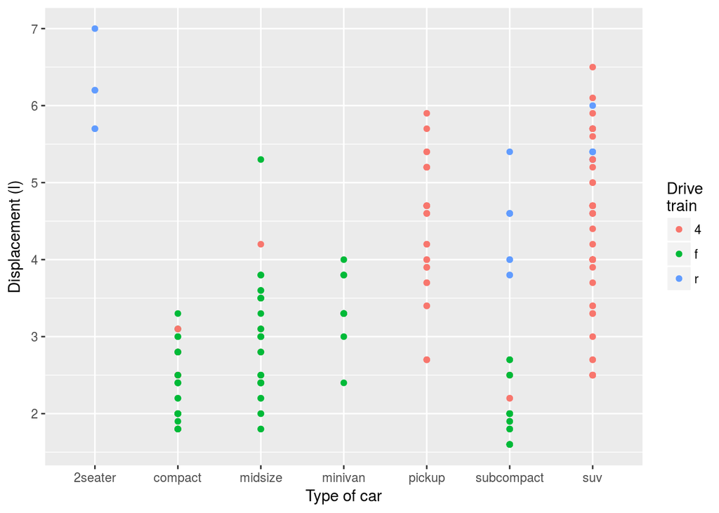

```r
#original:
ggplot(mpg, aes(y=displ,x=class)) + scale_y_continuous("Displacement (l)") + scale_x_discrete("Care type") + scale_x_discrete("Type of car") + scale_color_discrete() + geom_point(aes(color=drv)) + scale_color_discrete("Drive\ntrain")
```

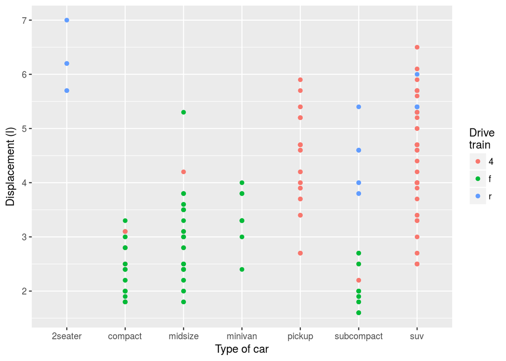

```r
#simplified version:
ggplot(mpg, aes(y=displ,x=class, color=drv)) + scale_y_continuous("Displacement (l)") + scale_x_discrete("Type of car") + geom_point() + scale_color_discrete("Drive\ntrain")
```

# 6.3.3 Exercises

1. Recreate the following graphic (see book):

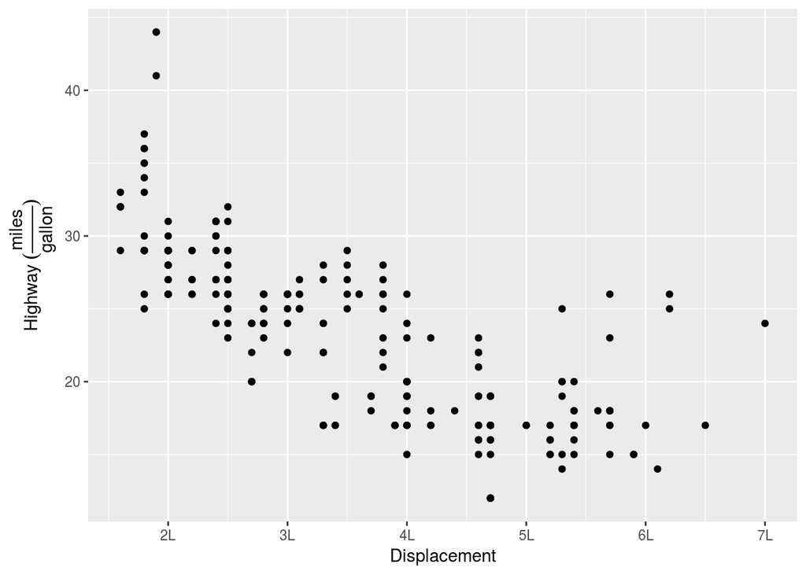

```r
ggplot(mpg,aes(displ,hwy)) + geom_point() + labs(x="Displacement",y= Highway~(frac(miles,gallon))) + scale_x_continuous(breaks = 2:7,labels=c("2L","3L","4L","5L","6L","7L"))
```

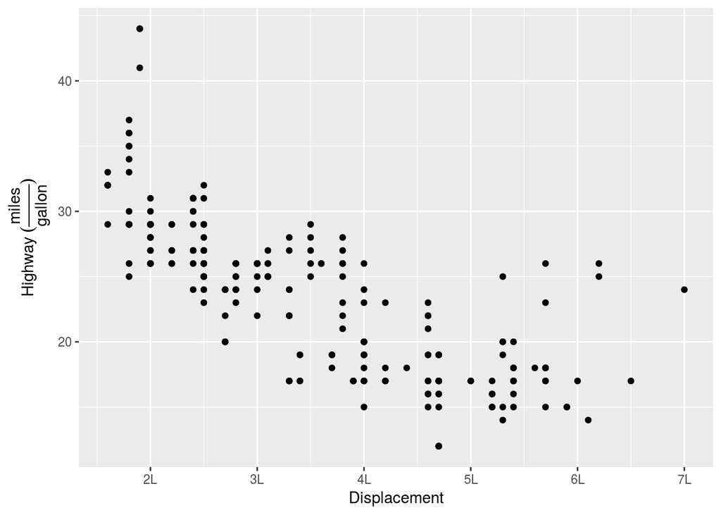

```r
ggplot(mpg,aes(displ,hwy)) + geom_point() + labs(x="Displacement",y= Highway~(frac(miles,gallon))) + scale_x_continuous(breaks = 2:7,labels=c("2L","3L","4L","5L","6L","7L"))
```

2. List the three different types of objects you an supply to the `breaks` argument. How do `breaks` and `labels` differ?

Three different object you can supply to `breaks`:

- vector
- function
- NULL

`breaks` are the positions of the grid lines and associated `labels`. `labels` are the text that label the `breaks`. `labels` needs to be same length as `breaks`.

3. Recreate the plot in the book:

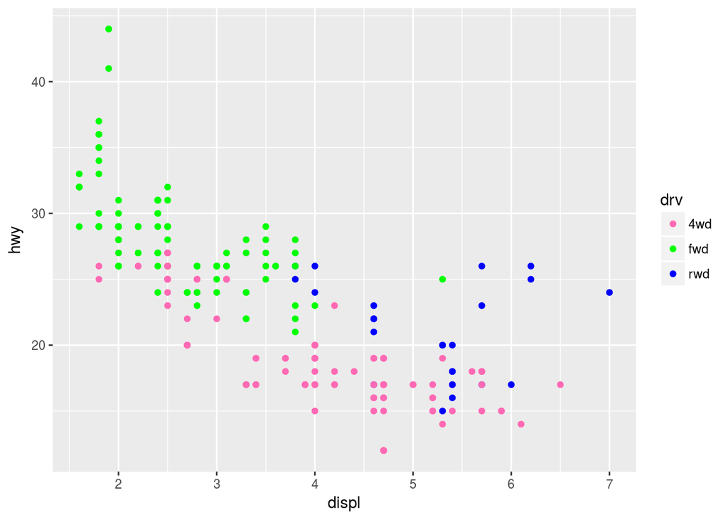

```r
ggplot(mpg,aes(displ,hwy,color=drv)) + geom_point() + scale_color_manual(labels = c("4wd", "fwd", "rwd"), values = c("hotpink", "green", "blue"))
```

4. What label function allows you to create mathematical expressions? What label function converts 1 to 1st, 2 to 2nd, and so on?

`expression` can be used with `labels` to create a mathematical expressions. Additionally, `scales::math_format` may be useful.

`scales::ordinal_format` can be used to convert 1 to 1st, 2 to 2nd, and so on.

5. What are the three most important arguments that apply to both axes and legends? What do they do? Compare and contrast their operation for axes vs legends.
- `name`: Name of the legend, axis label.
- `breaks`: Key of the legend, ticks and grid lines of the axes.
- `label`: Key label for the legend, tick labels for the axes.

# 6.4.4 Exercises

1. How do you make legends appear to the left of the plot?

`theme(legend.position = "left")`

2. What’s gone wrong with this plot? How could you fix it?

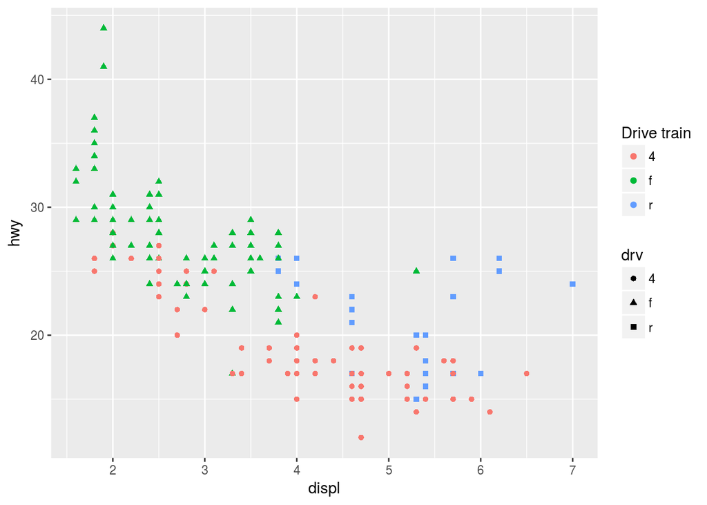

```r
ggplot(mpg,aes(displ,hwy)) + geom_point(aes(color=drv,shape=drv)) + scale_color_discrete("Drive train")
```

Two legends are being drawn (one for color, one for shape) because they have different names. We can fix this by getting rid of `+ scale_color_discrete("Drive train")`:

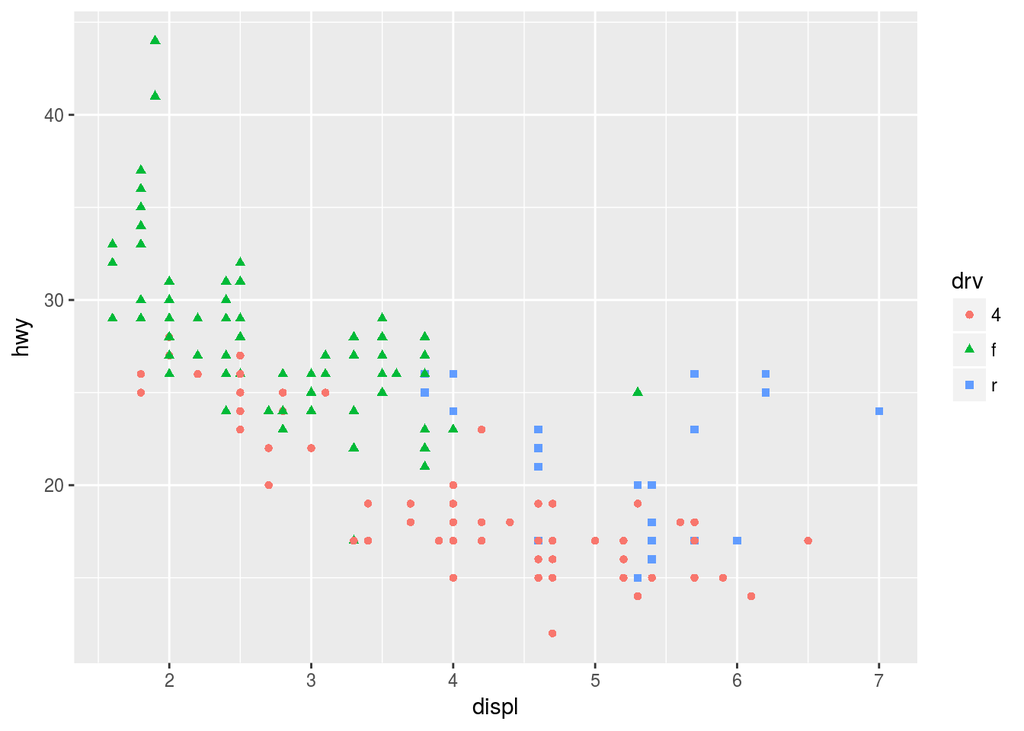

```r
ggplot(mpg,aes(displ,hwy)) + geom_point(aes(color=drv,shape=drv))
```

3. Can you recreate the code for this plot?

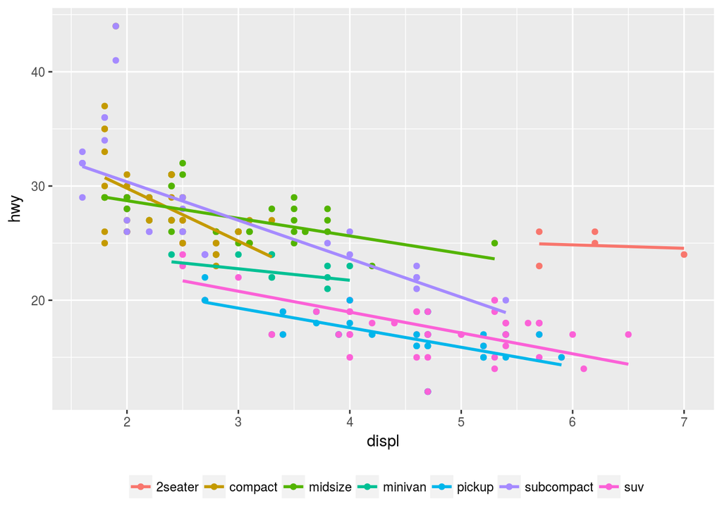

```r
ggplot(mpg,aes(displ,hwy,color=class)) + geom_point() + geom_smooth(method="lm",se=FALSE) + theme(legend.position = "bottom",legend.title = NULL) + guides(color = guide_legend(nrow = 1)) +
  theme(legend.title=element_blank())
```

# 6.5.1 Exercises

1. The following code creates two plots of the mpg dataset. Modify the code so that the legend and axes match, without using facetting!

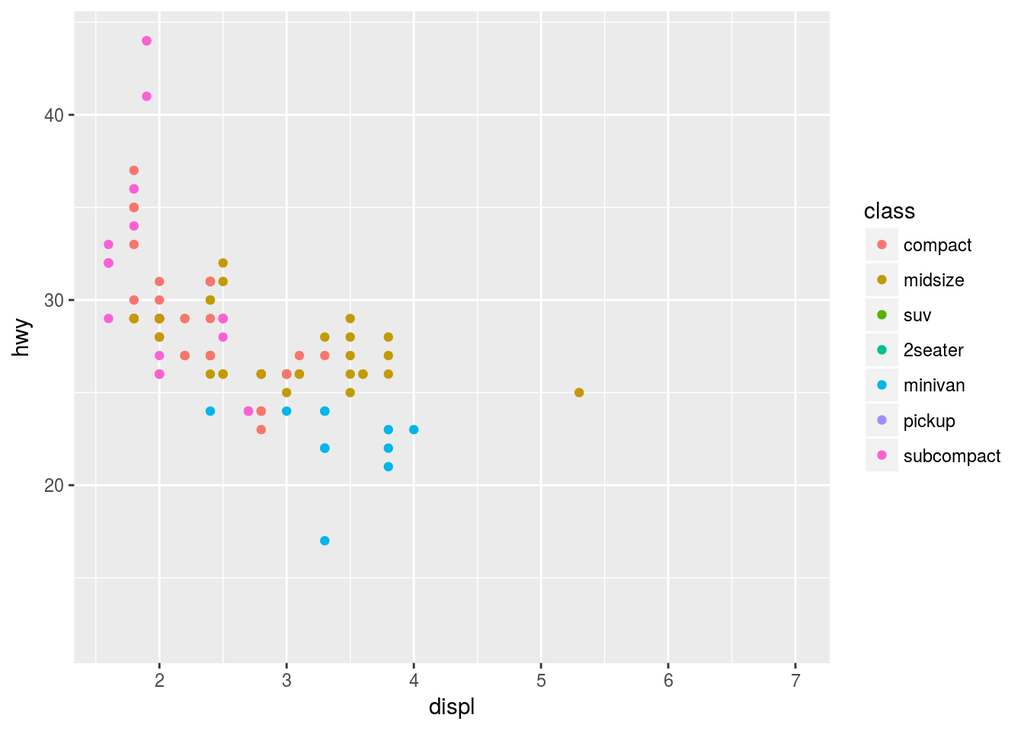

```r
fwd <- subset(mpg, drv=="f")
rwd <- subset(mpg, drv=="r")

x.min <- mpg %>% select(displ) %>% min()
x.max <- mpg %>% select(displ) %>% max()
y.min <- mpg %>% select(hwy) %>% min()
y.max <- mpg %>% select(hwy) %>% max()
class.unique <- mpg %>% select(class) %>% unique() %>% as.data.frame()

ggplot(fwd, aes(displ,hwy,color=class)) + geom_point() + scale_x_continuous(limits=c(x.min,x.max))+ scale_y_continuous(limits=c(y.min,y.max)) + scale_colour_discrete(limits = class.unique$class)
```

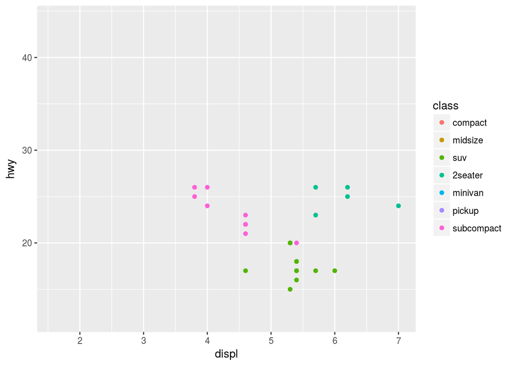

```r
ggplot(rwd, aes(displ,hwy,color=class)) + geom_point() + scale_x_continuous(limits=c(x.min,x.max)) + scale_y_continuous(limits=c(y.min,y.max)) + scale_colour_discrete(limits = class.unique$class)
```

2. What does `expand_limits()` do and how does it work? Read the source code.

It is used to expand the axis (or colorbar) limits to include additional points specified in the function. Useful for making sure all panels of a plot include a certain point.

Looking at the source code, it is a wrapper for geom_blank, which draws “nothing” (blank point).

3. What happens if you add two `xlim()` calls to the same plot? Why?

Here is an example:

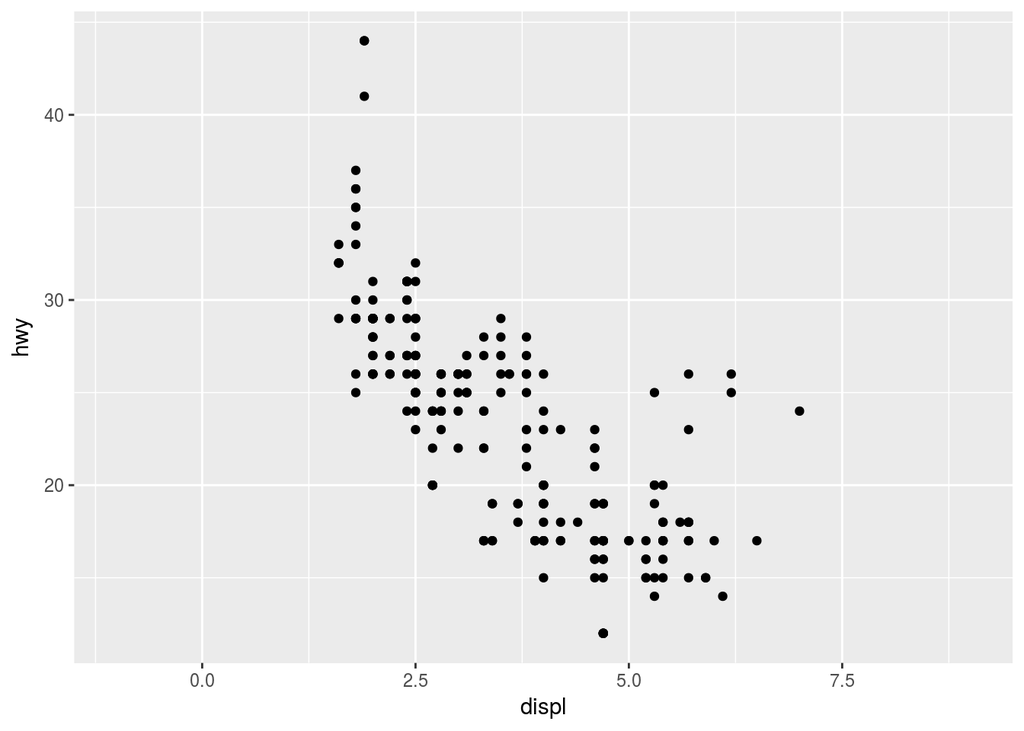

```r
ggplot(mpg, aes(displ,hwy)) + geom_point() + xlim(0,8) + xlim(-1,9)
```

The second `xlim` is used. The first is ignored.

4. What does `scale_x_continuous(limits = c(NA,NA))` do?

Example:

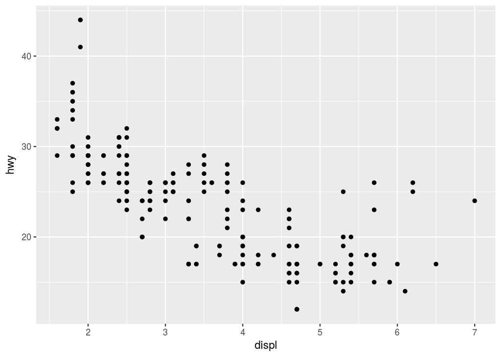

```r
p <- ggplot(mpg, aes(displ,hwy)) + geom_point()
p
```

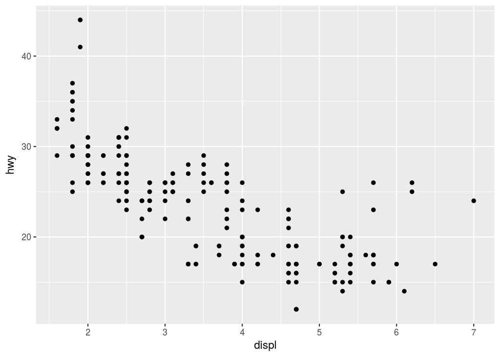

```r
p + scale_x_continuous(limits = c(NA,NA))
```

It doesn’t seem to do anything. The documentation says, “Use NA [for the limits argument] to refer to the existing minimum or maximum.”

# 6.6.5 Exercises

1. Compare and contrast the four continuous color scales with the four discrete scales.

| Continuous | Discrete |
| --- | --- |
| `scale_color_gradient()` | `scale_color_hue()` |
| `scale_color_gradient2()` | `scale_color_brewer()` |
| `scale_color_gradientn()` | `scale_color_grey()` |
| `scale_color_distiller()` | `scale_color_manual()` |

- **scale_color_gradient**: two-color gradient, low-high.
- **scale_color_gradient2**: three-color gradient, low-med-high.
- **scale_color_gradientn**: n-color gradient. Useful for colors that are meaningful for data.
- **scale_color_distiller**: apply the Color-Brewer color scales to continuous data.
- **scale_color_hue**: default for discrete data. Picks evenly spaced hues around the HCL color wheel. Works well for up to eight colors.
- **scale_color_brewer**: uses handpicked “ColorBrewer” colors that work well with different applications. See options at http:colorbrewer2.org.
- **scale_color_grey**: uses gray scale, from light to dark.
- **scale_color_manual**: Use for your own discrete color palette.
2. Explore the distribution of the buit-in `colors()` using the `luv_colors` dataset.

`colors()` returns all color names that R knows about. All built-in colors translate to the Luv color space.

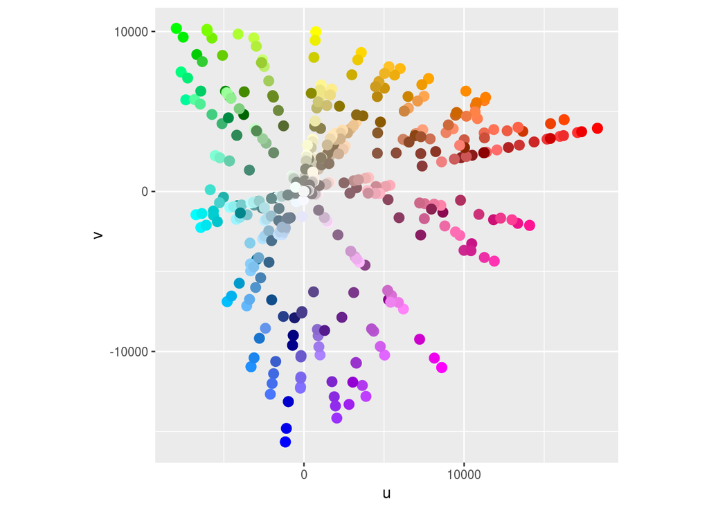

```r
#using the same code provided in the book, however, using the color() function instead of the "col"" column of luv_colours

ggplot(luv_colours, aes(u,v)) +
  geom_point(aes(color=colors()), size=3) +
  scale_color_identity() +
  coord_equal()
```